# Small Business Investment Analysis

Author

Austin Mangelson

This report analyzes the performance of six businesses over a two month period (*May 16th - July 18th*) based on the transaction data provided. The data includes daily transaction summaries to assess their growth potential and stability, in order to determine the best candidate to receive a business loan.

The businesses included in this report are:

1. LeBelle
2. Tacontento
3. Hot Diggity
4. Splash and Dash
5. Short Stop
6. Frozone

*Important note about the data: Although additional data was provided beyond this 2 month period, this was the only period of time in which we had data for all 6 businesses. A more comprehensive analysis could be done over a longer period of time provided more data on each business.

## Gross Revenue

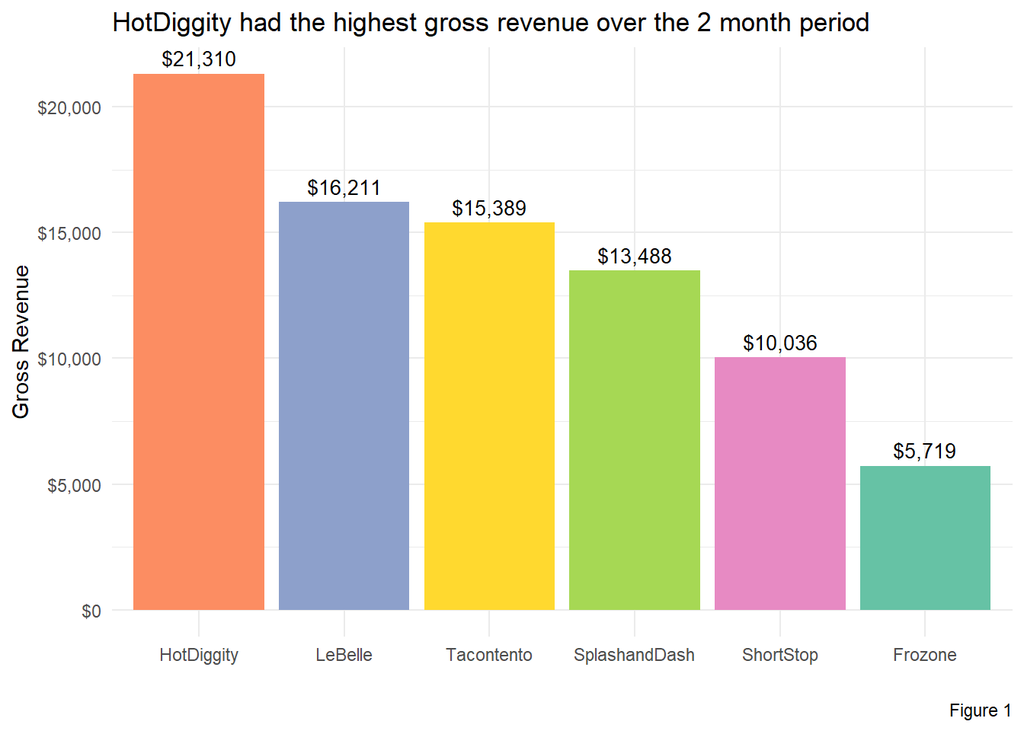

```r
data_tidy |>
  group_by(Name) |>
  summarise(gross_rev = sum(Amount)) |>
  ggplot(aes(x = reorder(Name, -gross_rev), y = gross_rev, fill = Name)) +
  geom_bar(stat = "identity") +
  scale_fill_manual(values = business_colors) +
  scale_y_continuous(labels = label_dollar(prefix = "$")) +
  geom_text(aes(label = dollar(round(gross_rev)), vjust = -0.5), size = 3.5) +
  theme_minimal() +
  theme(axis.title.y = element_text(angle = 90),
        legend.position = "none") +
  labs(
    title = "HotDiggity had the highest gross revenue over the 2 month period",
    x = "",
    y = "Gross Revenue",
    caption = "Figure 1"
  )
```

## Revenue Over Time

This table summarizes the peak revenue for each business across daily, weekly, and monthly periods.

| Business Name | Peak Daily Revenue | Peak Weekly Revenue | Peak Monthly Revenue |
| --- | --- | --- | --- |
| LeBelle | **$2,102** | **$4,590** | $7,048 |
| Tacontento | $1,550 | $3,194 | $6,319 |
| Hot Diggity | $990 | $3,086 | **$9,343** |
| Splash and Dash | $822 | $2,056 | $6,444 |
| Short Stop | $626 | $2,235 | $4,429 |
| Frozone | $447 | $1,364 | $2,898 |

Let’s take a look at how each business did over the two month period.

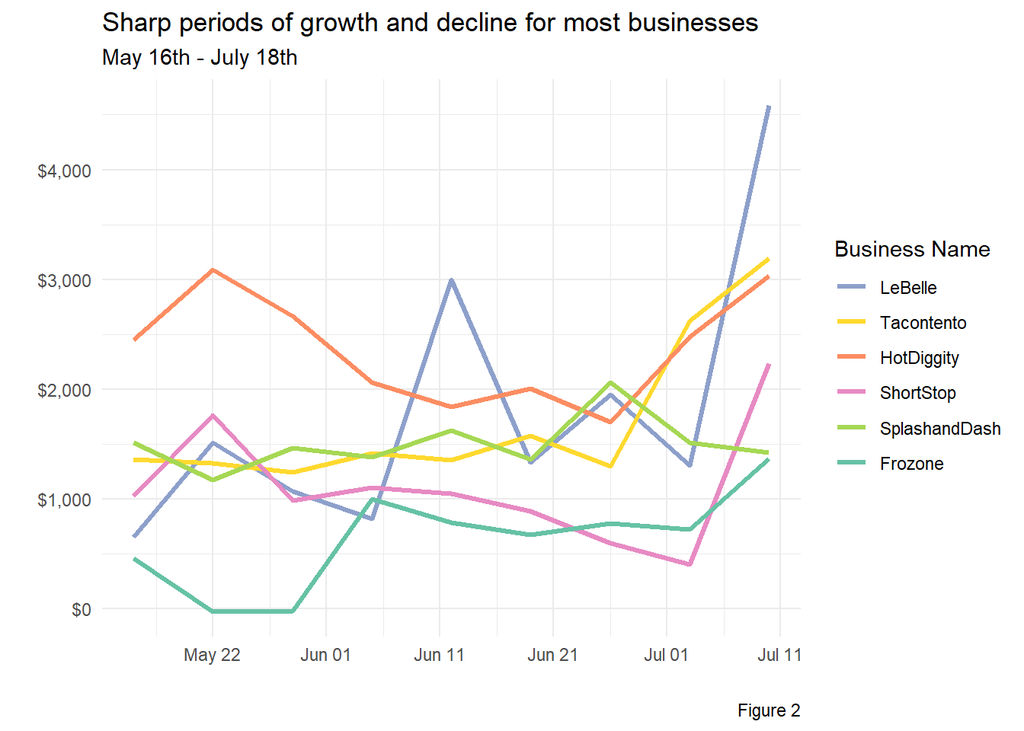

```r
data_tidy |>
  mutate(week = floor_date(date_time_MDT, "week")) |>
  group_by(Name, week) |>
  summarise(week_total = sum(Amount)) |>
  ggplot(aes(x = week, y = week_total, color = fct_reorder2(Name, week, week_total))) +
  geom_line(linewidth = 1.2) +
  scale_color_manual(values = business_colors) +
  scale_y_continuous(labels = label_dollar(prefix = "$")) +
  scale_x_datetime(breaks = "10 days",
                   date_labels = "%b %d") +
  theme(axis.title.y = element_text(angle = 90),
        legend.position = "right") +
  theme_minimal() +
  labs(
    title = "Sharp periods of growth and decline for most businesses",
    subtitle = "May 16th - July 18th",
    x = "",
    y = "",
    color = "Business Name",
    caption = "Figure 2"
  )
```

This graph tells an interesting story. We learn that many of the businesses had particularly successful or difficult weeks.

For example, LeBelle’s revenue spiked around June 13th and again starting around July 4th, while Hot Diggity, although the highest overall gross revenue earner and despite starting strong, shows a consistent decline throughout the end of May and all of June.

An interesting overall trend shows that most businesses increased revenue around July 4th, possibly due to seasonal effects and federal holidays which drove higher customer spending.

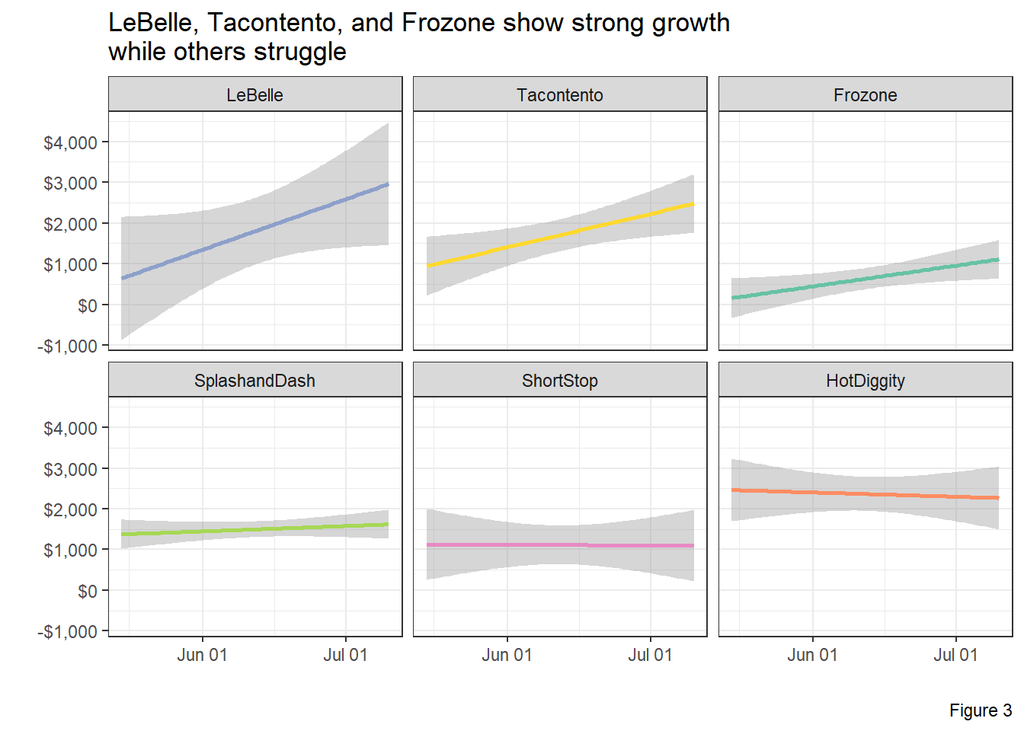

```r
slopes <- data_tidy %>%
  mutate(week = floor_date(date_time_MDT, "week")) %>%
  group_by(Name, week) %>%
  summarise(week_total = sum(Amount), .groups = 'drop') %>%
  group_by(Name) %>%
  summarise(slope = coef(lm(week_total ~ as.numeric(week)))[2], .groups = 'drop')

data_tidy |>
  mutate(week = floor_date(date_time_MDT, "week"),
         Name = factor(Name, levels = slopes$Name[order(slopes$slope, decreasing = TRUE)])) |>
  group_by(Name, week) |>
  summarise(week_total = sum(Amount)) |>
  ggplot(aes(x = week, y = week_total, color = Name)) +
  geom_smooth(method = "lm") +
  scale_color_manual(values = business_colors) +
  scale_y_continuous(labels = label_dollar(prefix = "$")) +
  scale_x_datetime(breaks = "1 month",
                   date_labels = "%b %d") +
  theme_bw() +
  theme(axis.title.y = element_text(angle = 90),
        legend.position = "none") +
  labs(
    title = "LeBelle, Tacontento, and Frozone show strong growth \nwhile others struggle",
    x = "",
    y = "",
    color = "Business Name",
    caption = "Figure 3"
  ) +
  facet_wrap(~Name)
```

This plot helps us more clearly see revenue trends of each business, and makes it clear that LeBelle leads the way with the most promising revenue forecast, followed by Tacontento and Frozone.

## Transaction Values

Finally, let’s take a look at the transaction values for each business.

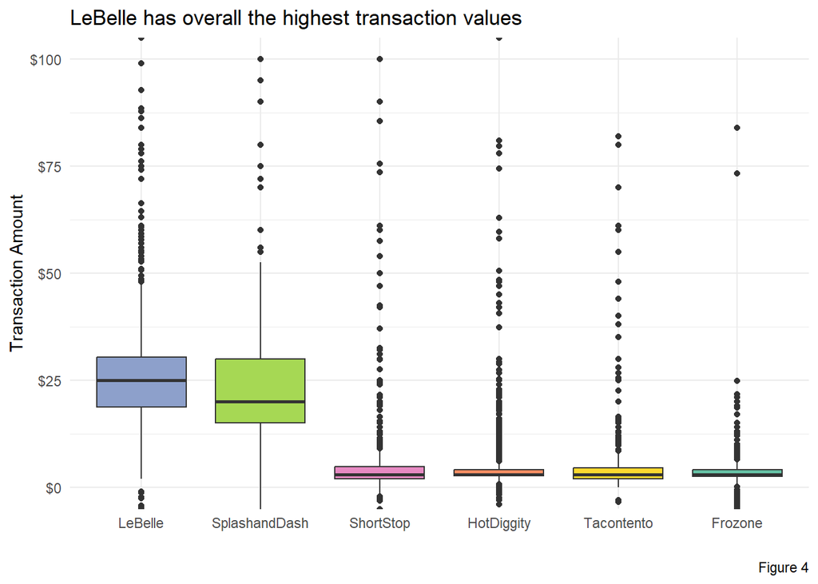

```r
data_tidy |>
  group_by(Name) |>
  ggplot(aes(x = reorder(Name, -Amount), y = Amount, fill = Name)) +
  geom_boxplot() +
  #geom_jitter(alpha = 0.25, width = 0.3) +
  coord_cartesian(ylim = c(0, 100)) +
  scale_fill_manual(values = business_colors) +
  scale_y_continuous(labels = label_dollar(prefix = "$")) +
  theme_minimal() +
  theme(legend.position = "none",
        axis.title.y = element_text(angle = 90)) +
  labs(
    title = "LeBelle has overall the highest transaction values",
    x = "",
    y = "Transaction Amount",
    caption = "Figure 4"
  )
```

## Risks and Considerations:

Further due diligence is necessary to understand the reasons behind LeBelle’s success, along with potential risks associated with their business model.

While LeBelle seems to be the strongest candidate, we’ve only looked at revenue data in a relatively short time period. Other factors beyond revenue, such as the size of the target market, scalability of the business model, and the competitive landscape, should be considered before making an investment decision.

```r
data_tidy |>
  mutate(Hour = hour(date_time_MDT)) |>
  group_by(Name, Hour) |>
  summarise(Transactions = n(), .groups = 'drop') |>
  ggplot(aes(x = Hour, y = Transactions, fill = Name)) +
  geom_bar(stat = "identity", position = "dodge") +
  scale_x_continuous(n.breaks = 8) +
  scale_fill_manual(values = business_colors) +
  theme_hc() +
  theme(legend.position = "none",
        axis.title.y = element_text(angle = 90)) +
  facet_wrap(~Name, scales = "free_x") +
  labs(
    title = "Transactions by the Hour",
    subtitle = "May 16th - July 18th",
    x = "Hour (military time)",
    y = "Number of Transactions"
  )

#What are the peak revenue days for each business?

data_tidy |>
  mutate(day = floor_date(date_time_MDT, "day")) |>
  group_by(Name, day) |>
  summarise(daily_total = sum(Amount)) |>
  summarise(`Daily Max` = max(daily_total),
            `Daily Min` = min(daily_total)) |>
  pivot_longer(names_to = "type", values_to = "amount", -Name) |>
  ggplot(aes(x = reorder(Name, -amount), amount, fill = type)) +
  geom_bar(stat = "identity", position = "dodge", width = 0.7) +
  theme(legend.position = "right",
        axis.title.y = element_text(angle = 90)) +
  scale_y_continuous(labels = label_dollar(prefix = "$")) +
  labs(
    title = "LeBelle had the highest peak revenue day",
    subtitle = "Shortstop had the lowest",
    x = "",
    y = "Daily Revenue",
    fill = ""
  )

#What are the peak revenue weeks for each business?

data_tidy |>
  mutate(week = floor_date(date_time_MDT, "week")) |>
  group_by(Name, week) |>
  summarise(weekly_total = sum(Amount)) |>
  summarise(`Weekly Max` = max(weekly_total),
            `Weekly Min` = min(weekly_total)) |>
  pivot_longer(names_to = "type", values_to = "amount", -Name) |>
  ggplot(aes(x = reorder(Name, -amount), amount, fill = type)) +
  geom_bar(stat = "identity", position = "dodge", width = 0.7) +
  theme(legend.position = "right",
        axis.title.y = element_text(angle = 90)) +
  scale_y_continuous(labels = label_dollar(prefix = "$")) +
  labs(
    title = "LeBelle had the highest peak revenue week",
    subtitle = "Frozone had the lowest",
    x = "",
    y = "Weekly Revenue",
    fill = ""
  )

#What are the peak revenue months for each business?

data_tidy |>
  mutate(month = floor_date(date_time_MDT, "month")) |>
  group_by(Name, month) |>
  summarise(monthly_total = sum(Amount)) |>
  summarise(`Monthly Max` = max(monthly_total),
            `Monthly Min` = min(monthly_total)) |>
  pivot_longer(names_to = "type", values_to = "amount", -Name) |>
  ggplot(aes(x = reorder(Name, -amount), amount, fill = type)) +
  geom_bar(stat = "identity", position = "dodge", width = 0.7) +
  theme(legend.position = "right",
        axis.title.y = element_text(angle = 90)) +
  scale_y_continuous(labels = label_dollar(prefix = "$")) +
  labs(
    title = "HotDigitty had the highest peak revenue month",
    subtitle = "Frozone had the lowest",
    x = "",
    y = "Monthly Revenue",
    fill = ""
  )
```

[output not shown]